# Risk Factor Analysis

## Outcome Variable

**Outcome Variable:** haz

## Predictor Variables

**Intervention Variable:** vagbrth

**Adjustment Set:**

- arm
- sex
- W_mage
- meducyrs
- feducyrs
- hhwealth_quart
- W_mhtcm
- W_mwtkg
- W_mbmi
- single
- W_nrooms
- brthmon
- W_parity
- impfloor
- impsan
- safeh20
- delta_W_mage
- delta_meducyrs
- delta_feducyrs
- delta_hhwealth_quart
- delta_W_mhtcm
- delta_W_mwtkg
- delta_W_mbmi
- delta_single
- delta_W_nrooms
- delta_brthmon
- delta_W_parity
- delta_impfloor
- delta_impsan
- delta_safeh20

## Stratifying Variables

The analysis was stratified on these variable(s):

- agecat
- studyid
- country

## Data Summary

| agecat | studyid | country | vagbrth | n_cell | n |
| --- | --- | --- | --- | --- | --- |
| Birth | ki1000108-CMC-V-BCS-2002 | INDIA | 0 | 11 | 92 |
| Birth | ki1000108-CMC-V-BCS-2002 | INDIA | 1 | 81 | 92 |
| Birth | ki1000108-IRC | INDIA | 0 | 68 | 388 |
| Birth | ki1000108-IRC | INDIA | 1 | 320 | 388 |
| Birth | ki1017093b-PROVIDE | BANGLADESH | 0 | 108 | 539 |
| Birth | ki1017093b-PROVIDE | BANGLADESH | 1 | 431 | 539 |
| Birth | ki1017093c-NIH-Crypto | BANGLADESH | 0 | 186 | 477 |
| Birth | ki1017093c-NIH-Crypto | BANGLADESH | 1 | 291 | 477 |
| Birth | ki1119695-PROBIT | BELARUS | 0 | 1597 | 13890 |
| Birth | ki1119695-PROBIT | BELARUS | 1 | 12293 | 13890 |
| Birth | ki1126311-ZVITAMBO | ZIMBABWE | 0 | 1166 | 13761 |
| Birth | ki1126311-ZVITAMBO | ZIMBABWE | 1 | 12595 | 13761 |
| Birth | kiGH5241-JiVitA-3 | BANGLADESH | 0 | 1472 | 26599 |
| Birth | kiGH5241-JiVitA-3 | BANGLADESH | 1 | 25127 | 26599 |
| Birth | kiGH5241-JiVitA-4 | BANGLADESH | 0 | 76 | 2822 |
| Birth | kiGH5241-JiVitA-4 | BANGLADESH | 1 | 2746 | 2822 |
| 6 months | ki1000108-CMC-V-BCS-2002 | INDIA | 0 | 25 | 369 |
| 6 months | ki1000108-CMC-V-BCS-2002 | INDIA | 1 | 344 | 369 |
| 6 months | ki1000108-IRC | INDIA | 0 | 69 | 407 |
| 6 months | ki1000108-IRC | INDIA | 1 | 338 | 407 |
| 6 months | ki1017093b-PROVIDE | BANGLADESH | 0 | 139 | 604 |
| 6 months | ki1017093b-PROVIDE | BANGLADESH | 1 | 465 | 604 |
| 6 months | ki1017093c-NIH-Crypto | BANGLADESH | 0 | 187 | 457 |
| 6 months | ki1017093c-NIH-Crypto | BANGLADESH | 1 | 270 | 457 |
| 6 months | ki1066203-TanzaniaChild2 | TANZANIA, UNITED REPUBLIC OF | 0 | 189 | 2005 |
| 6 months | ki1066203-TanzaniaChild2 | TANZANIA, UNITED REPUBLIC OF | 1 | 1816 | 2005 |
| 6 months | ki1119695-PROBIT | BELARUS | 0 | 1799 | 15761 |
| 6 months | ki1119695-PROBIT | BELARUS | 1 | 13962 | 15761 |
| 6 months | ki1126311-ZVITAMBO | ZIMBABWE | 0 | 740 | 8601 |
| 6 months | ki1126311-ZVITAMBO | ZIMBABWE | 1 | 7861 | 8601 |
| 6 months | kiGH5241-JiVitA-3 | BANGLADESH | 0 | 1071 | 16675 |
| 6 months | kiGH5241-JiVitA-3 | BANGLADESH | 1 | 15604 | 16675 |
| 6 months | kiGH5241-JiVitA-4 | BANGLADESH | 0 | 336 | 4052 |
| 6 months | kiGH5241-JiVitA-4 | BANGLADESH | 1 | 3716 | 4052 |
| 24 months | ki1000108-CMC-V-BCS-2002 | INDIA | 0 | 24 | 371 |
| 24 months | ki1000108-CMC-V-BCS-2002 | INDIA | 1 | 347 | 371 |
| 24 months | ki1000108-IRC | INDIA | 0 | 69 | 409 |
| 24 months | ki1000108-IRC | INDIA | 1 | 340 | 409 |
| 24 months | ki1017093b-PROVIDE | BANGLADESH | 0 | 137 | 578 |
| 24 months | ki1017093b-PROVIDE | BANGLADESH | 1 | 441 | 578 |
| 24 months | ki1017093c-NIH-Crypto | BANGLADESH | 0 | 99 | 260 |
| 24 months | ki1017093c-NIH-Crypto | BANGLADESH | 1 | 161 | 260 |
| 24 months | ki1066203-TanzaniaChild2 | TANZANIA, UNITED REPUBLIC OF | 0 | 2 | 6 |
| 24 months | ki1066203-TanzaniaChild2 | TANZANIA, UNITED REPUBLIC OF | 1 | 4 | 6 |
| 24 months | ki1119695-PROBIT | BELARUS | 0 | 472 | 4035 |
| 24 months | ki1119695-PROBIT | BELARUS | 1 | 3563 | 4035 |
| 24 months | ki1126311-ZVITAMBO | ZIMBABWE | 0 | 133 | 1619 |
| 24 months | ki1126311-ZVITAMBO | ZIMBABWE | 1 | 1486 | 1619 |
| 24 months | kiGH5241-JiVitA-3 | BANGLADESH | 0 | 476 | 8517 |
| 24 months | kiGH5241-JiVitA-3 | BANGLADESH | 1 | 8041 | 8517 |
| 24 months | kiGH5241-JiVitA-4 | BANGLADESH | 0 | 323 | 4020 |
| 24 months | kiGH5241-JiVitA-4 | BANGLADESH | 1 | 3697 | 4020 |

The following strata were considered:

- agecat: 24 months, studyid: ki1000108-CMC-V-BCS-2002, country: INDIA
- agecat: 24 months, studyid: ki1000108-IRC, country: INDIA
- agecat: 24 months, studyid: ki1017093b-PROVIDE, country: BANGLADESH
- agecat: 24 months, studyid: ki1017093c-NIH-Crypto, country: BANGLADESH
- agecat: 24 months, studyid: ki1066203-TanzaniaChild2, country: TANZANIA, UNITED REPUBLIC OF
- agecat: 24 months, studyid: ki1119695-PROBIT, country: BELARUS
- agecat: 24 months, studyid: ki1126311-ZVITAMBO, country: ZIMBABWE
- agecat: 24 months, studyid: kiGH5241-JiVitA-3, country: BANGLADESH
- agecat: 24 months, studyid: kiGH5241-JiVitA-4, country: BANGLADESH
- agecat: 6 months, studyid: ki1000108-CMC-V-BCS-2002, country: INDIA
- agecat: 6 months, studyid: ki1000108-IRC, country: INDIA
- agecat: 6 months, studyid: ki1017093b-PROVIDE, country: BANGLADESH
- agecat: 6 months, studyid: ki1017093c-NIH-Crypto, country: BANGLADESH
- agecat: 6 months, studyid: ki1066203-TanzaniaChild2, country: TANZANIA, UNITED REPUBLIC OF
- agecat: 6 months, studyid: ki1119695-PROBIT, country: BELARUS
- agecat: 6 months, studyid: ki1126311-ZVITAMBO, country: ZIMBABWE
- agecat: 6 months, studyid: kiGH5241-JiVitA-3, country: BANGLADESH
- agecat: 6 months, studyid: kiGH5241-JiVitA-4, country: BANGLADESH
- agecat: Birth, studyid: ki1000108-CMC-V-BCS-2002, country: INDIA
- agecat: Birth, studyid: ki1000108-IRC, country: INDIA
- agecat: Birth, studyid: ki1017093b-PROVIDE, country: BANGLADESH
- agecat: Birth, studyid: ki1017093c-NIH-Crypto, country: BANGLADESH
- agecat: Birth, studyid: ki1119695-PROBIT, country: BELARUS
- agecat: Birth, studyid: ki1126311-ZVITAMBO, country: ZIMBABWE
- agecat: Birth, studyid: kiGH5241-JiVitA-3, country: BANGLADESH
- agecat: Birth, studyid: kiGH5241-JiVitA-4, country: BANGLADESH

### Dropped Strata

Some strata were dropped due to rare outcomes:

- agecat: 24 months, studyid: ki1066203-TanzaniaChild2, country: TANZANIA, UNITED REPUBLIC OF

## Methods Detail

We’re interested in the causal parameters $E[Y_a]$ for all values of $a \in \mathcal{A}$. These parameters represent the mean outcome if, possibly contrary to fact, we intervened to set all units to have $A=a$. Under the randomization and positivity assumptions, these are identified by the statistical parameters $\psi_a=E_W[E_{Y|A,W}(Y|A=a,W)]$. In addition, we’re interested in the mean of $Y$, $E[Y]$ under no intervention (the observed mean). We will estimate these parameters by using SuperLearner to fit the relevant likelihood factors – $E_{Y|A,W}(Y|A=a,W)$ and $p(A=a|W)$, and then updating our likelihood fit using a joint TMLE.

For unadjusted analyses ($W=\{\}$), initial likelihoods were estimated using Lrnr_glm to estimate the simple $E(Y|A)$ and Lrnr_mean to estimate $p(A)$. For adjusted analyses, a small library containing Lrnr_glmnet, Lrnr_xgboost, and Lrnr_mean was used.

Having estimated these parameters, we will then use the delta method to estimate relative risks and attributable risks relative to a prespecified baseline level of $A$.

# Results Detail

## Results Plots

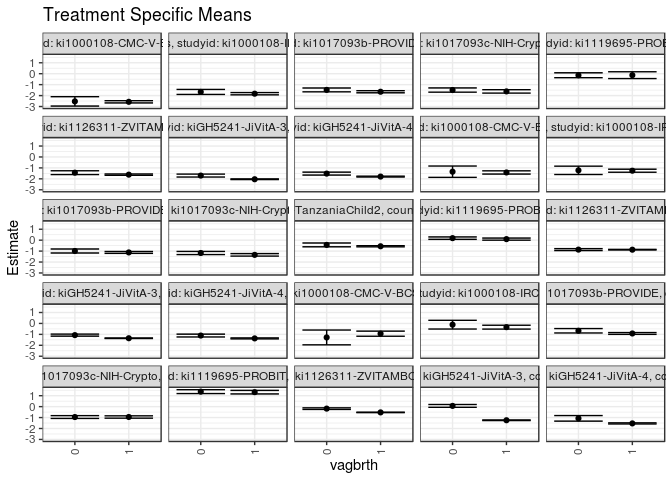

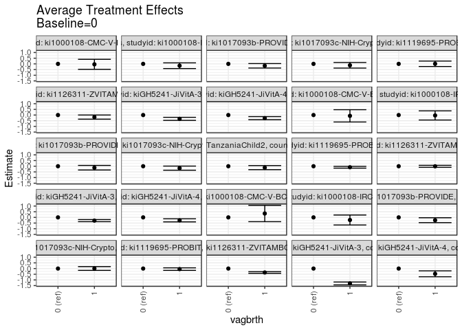

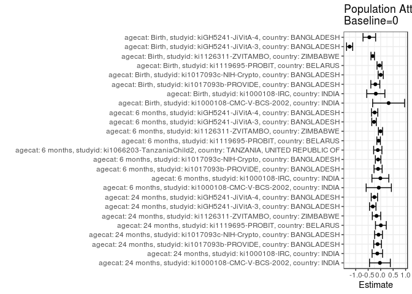

## Results Table

### Parameter: TSM

| agecat | studyid | country | intervention_level | baseline_level | estimate | ci_lower | ci_upper |
| --- | --- | --- | --- | --- | --- | --- | --- |
| Birth | ki1000108-CMC-V-BCS-2002 | INDIA | 0 | NA | -1.2809834 | -1.9576507 | -0.6043160 |
| Birth | ki1000108-CMC-V-BCS-2002 | INDIA | 1 | NA | -0.9384504 | -1.1703464 | -0.7065544 |
| Birth | ki1000108-IRC | INDIA | 0 | NA | -0.1143439 | -0.5144077 | 0.2857198 |
| Birth | ki1000108-IRC | INDIA | 1 | NA | -0.3435574 | -0.5196660 | -0.1674488 |
| Birth | ki1017093b-PROVIDE | BANGLADESH | 0 | NA | -0.6720791 | -0.8735199 | -0.4706383 |
| Birth | ki1017093b-PROVIDE | BANGLADESH | 1 | NA | -0.9203470 | -1.0021308 | -0.8385632 |
| Birth | ki1017093c-NIH-Crypto | BANGLADESH | 0 | NA | -0.9503645 | -1.0796105 | -0.8211184 |
| Birth | ki1017093c-NIH-Crypto | BANGLADESH | 1 | NA | -0.9456824 | -1.0519376 | -0.8394272 |
| Birth | ki1119695-PROBIT | BELARUS | 0 | NA | 1.3728389 | 1.1953998 | 1.5502779 |
| Birth | ki1119695-PROBIT | BELARUS | 1 | NA | 1.3243359 | 1.1634612 | 1.4852106 |
| Birth | ki1126311-ZVITAMBO | ZIMBABWE | 0 | NA | -0.1802738 | -0.2533800 | -0.1071676 |
| Birth | ki1126311-ZVITAMBO | ZIMBABWE | 1 | NA | -0.5262246 | -0.5477571 | -0.5046920 |
| Birth | kiGH5241-JiVitA-3 | BANGLADESH | 0 | NA | 0.0682738 | -0.0610171 | 0.1975647 |
| Birth | kiGH5241-JiVitA-3 | BANGLADESH | 1 | NA | -1.2432208 | -1.2691428 | -1.2172987 |
| Birth | kiGH5241-JiVitA-4 | BANGLADESH | 0 | NA | -1.0698564 | -1.3250662 | -0.8146466 |
| Birth | kiGH5241-JiVitA-4 | BANGLADESH | 1 | NA | -1.5329145 | -1.5829442 | -1.4828848 |
| 6 months | ki1000108-CMC-V-BCS-2002 | INDIA | 0 | NA | -1.3482230 | -1.8655879 | -0.8308582 |
| 6 months | ki1000108-CMC-V-BCS-2002 | INDIA | 1 | NA | -1.4186040 | -1.5658240 | -1.2713840 |
| 6 months | ki1000108-IRC | INDIA | 0 | NA | -1.2233796 | -1.6049706 | -0.8417887 |
| 6 months | ki1000108-IRC | INDIA | 1 | NA | -1.2579842 | -1.3954844 | -1.1204840 |
| 6 months | ki1017093b-PROVIDE | BANGLADESH | 0 | NA | -0.9886504 | -1.1713837 | -0.8059172 |
| 6 months | ki1017093b-PROVIDE | BANGLADESH | 1 | NA | -1.1194724 | -1.2045722 | -1.0343727 |
| 6 months | ki1017093c-NIH-Crypto | BANGLADESH | 0 | NA | -1.1721125 | -1.3155655 | -1.0286594 |
| 6 months | ki1017093c-NIH-Crypto | BANGLADESH | 1 | NA | -1.3426530 | -1.4573646 | -1.2279414 |
| 6 months | ki1066203-TanzaniaChild2 | TANZANIA, UNITED REPUBLIC OF | 0 | NA | -0.4309422 | -0.6042264 | -0.2576581 |
| 6 months | ki1066203-TanzaniaChild2 | TANZANIA, UNITED REPUBLIC OF | 1 | NA | -0.5558510 | -0.6076110 | -0.5040911 |
| 6 months | ki1119695-PROBIT | BELARUS | 0 | NA | 0.1878695 | 0.0786710 | 0.2970680 |
| 6 months | ki1119695-PROBIT | BELARUS | 1 | NA | 0.0972495 | 0.0007556 | 0.1937435 |
| 6 months | ki1126311-ZVITAMBO | ZIMBABWE | 0 | NA | -0.8621723 | -0.9481699 | -0.7761746 |
| 6 months | ki1126311-ZVITAMBO | ZIMBABWE | 1 | NA | -0.8696362 | -0.8966038 | -0.8426685 |
| 6 months | kiGH5241-JiVitA-3 | BANGLADESH | 0 | NA | -1.0709190 | -1.1635450 | -0.9782929 |
| 6 months | kiGH5241-JiVitA-3 | BANGLADESH | 1 | NA | -1.3554841 | -1.3785379 | -1.3324302 |
| 6 months | kiGH5241-JiVitA-4 | BANGLADESH | 0 | NA | -1.1105382 | -1.2410019 | -0.9800745 |
| 6 months | kiGH5241-JiVitA-4 | BANGLADESH | 1 | NA | -1.3701229 | -1.4139462 | -1.3262996 |
| 24 months | ki1000108-CMC-V-BCS-2002 | INDIA | 0 | NA | -2.5296754 | -2.9587283 | -2.1006225 |
| 24 months | ki1000108-CMC-V-BCS-2002 | INDIA | 1 | NA | -2.5691546 | -2.6719382 | -2.4663710 |
| 24 months | ki1000108-IRC | INDIA | 0 | NA | -1.6658040 | -1.8928700 | -1.4387380 |
| 24 months | ki1000108-IRC | INDIA | 1 | NA | -1.8266141 | -1.9299266 | -1.7233015 |
| 24 months | ki1017093b-PROVIDE | BANGLADESH | 0 | NA | -1.4802367 | -1.6548175 | -1.3056559 |
| 24 months | ki1017093b-PROVIDE | BANGLADESH | 1 | NA | -1.6493202 | -1.7438506 | -1.5547897 |
| 24 months | ki1017093c-NIH-Crypto | BANGLADESH | 0 | NA | -1.4927496 | -1.6851703 | -1.3003288 |
| 24 months | ki1017093c-NIH-Crypto | BANGLADESH | 1 | NA | -1.6173782 | -1.7740933 | -1.4606631 |
| 24 months | ki1119695-PROBIT | BELARUS | 0 | NA | -0.1411246 | -0.3658859 | 0.0836367 |
| 24 months | ki1119695-PROBIT | BELARUS | 1 | NA | -0.1326382 | -0.4432772 | 0.1780007 |
| 24 months | ki1126311-ZVITAMBO | ZIMBABWE | 0 | NA | -1.4386946 | -1.6128111 | -1.2645782 |
| 24 months | ki1126311-ZVITAMBO | ZIMBABWE | 1 | NA | -1.6187768 | -1.6789333 | -1.5586204 |
| 24 months | kiGH5241-JiVitA-3 | BANGLADESH | 0 | NA | -1.7042723 | -1.8385933 | -1.5699513 |
| 24 months | kiGH5241-JiVitA-3 | BANGLADESH | 1 | NA | -2.0381772 | -2.0656203 | -2.0107342 |
| 24 months | kiGH5241-JiVitA-4 | BANGLADESH | 0 | NA | -1.5228755 | -1.6565561 | -1.3891950 |
| 24 months | kiGH5241-JiVitA-4 | BANGLADESH | 1 | NA | -1.7945999 | -1.8339656 | -1.7552342 |

### Parameter: E(Y)

| agecat | studyid | country | intervention_level | baseline_level | estimate | ci_lower | ci_upper |
| --- | --- | --- | --- | --- | --- | --- | --- |
| Birth | ki1000108-CMC-V-BCS-2002 | INDIA | NA | NA | -0.9611957 | -1.1776967 | -0.7446946 |
| Birth | ki1000108-IRC | INDIA | NA | NA | -0.3080412 | -0.4687931 | -0.1472894 |
| Birth | ki1017093b-PROVIDE | BANGLADESH | NA | NA | -0.8851020 | -0.9601332 | -0.8100709 |
| Birth | ki1017093c-NIH-Crypto | BANGLADESH | NA | NA | -0.9480084 | -1.0301396 | -0.8658772 |
| Birth | ki1119695-PROBIT | BELARUS | NA | NA | 1.3269446 | 1.1683850 | 1.4855041 |
| Birth | ki1126311-ZVITAMBO | ZIMBABWE | NA | NA | -0.4970772 | -0.5177022 | -0.4764523 |
| Birth | kiGH5241-JiVitA-3 | BANGLADESH | NA | NA | -1.1739746 | -1.2019520 | -1.1459972 |
| Birth | kiGH5241-JiVitA-4 | BANGLADESH | NA | NA | -1.5231680 | -1.5722488 | -1.4740872 |
| 6 months | ki1000108-CMC-V-BCS-2002 | INDIA | NA | NA | -1.4234508 | -1.5645974 | -1.2823042 |
| 6 months | ki1000108-IRC | INDIA | NA | NA | -1.2344062 | -1.3658524 | -1.1029600 |
| 6 months | ki1017093b-PROVIDE | BANGLADESH | NA | NA | -1.0916915 | -1.1661176 | -1.0172654 |
| 6 months | ki1017093c-NIH-Crypto | BANGLADESH | NA | NA | -1.2731619 | -1.3626957 | -1.1836282 |
| 6 months | ki1066203-TanzaniaChild2 | TANZANIA, UNITED REPUBLIC OF | NA | NA | -0.5455565 | -0.5948696 | -0.4962435 |
| 6 months | ki1119695-PROBIT | BELARUS | NA | NA | 0.1069986 | 0.0122286 | 0.2017686 |
| 6 months | ki1126311-ZVITAMBO | ZIMBABWE | NA | NA | -0.8685914 | -0.8942954 | -0.8428875 |
| 6 months | kiGH5241-JiVitA-3 | BANGLADESH | NA | NA | -1.3358351 | -1.3589861 | -1.3126841 |
| 6 months | kiGH5241-JiVitA-4 | BANGLADESH | NA | NA | -1.3500888 | -1.3921730 | -1.3080047 |
| 24 months | ki1000108-CMC-V-BCS-2002 | INDIA | NA | NA | -2.5588679 | -2.6583730 | -2.4593629 |
| 24 months | ki1000108-IRC | INDIA | NA | NA | -1.7987775 | -1.8923914 | -1.7051636 |
| 24 months | ki1017093b-PROVIDE | BANGLADESH | NA | NA | -1.6024221 | -1.6857420 | -1.5191023 |
| 24 months | ki1017093c-NIH-Crypto | BANGLADESH | NA | NA | -1.5776538 | -1.6988448 | -1.4564629 |
| 24 months | ki1119695-PROBIT | BELARUS | NA | NA | -0.1314048 | -0.4282725 | 0.1654630 |
| 24 months | ki1126311-ZVITAMBO | ZIMBABWE | NA | NA | -1.6043391 | -1.6616652 | -1.5470130 |
| 24 months | kiGH5241-JiVitA-3 | BANGLADESH | NA | NA | -2.0204086 | -2.0480344 | -1.9927828 |
| 24 months | kiGH5241-JiVitA-4 | BANGLADESH | NA | NA | -1.7734527 | -1.8119258 | -1.7349797 |

### Parameter: ATE

| agecat | studyid | country | intervention_level | baseline_level | estimate | ci_lower | ci_upper |
| --- | --- | --- | --- | --- | --- | --- | --- |
| Birth | ki1000108-CMC-V-BCS-2002 | INDIA | 0 | 0 | 0.0000000 | 0.0000000 | 0.0000000 |
| Birth | ki1000108-CMC-V-BCS-2002 | INDIA | 1 | 0 | 0.3425329 | -0.3771616 | 1.0622275 |
| Birth | ki1000108-IRC | INDIA | 0 | 0 | 0.0000000 | 0.0000000 | 0.0000000 |
| Birth | ki1000108-IRC | INDIA | 1 | 0 | -0.2292134 | -0.6682002 | 0.2097733 |
| Birth | ki1017093b-PROVIDE | BANGLADESH | 0 | 0 | 0.0000000 | 0.0000000 | 0.0000000 |
| Birth | ki1017093b-PROVIDE | BANGLADESH | 1 | 0 | -0.2482679 | -0.4648368 | -0.0316989 |
| Birth | ki1017093c-NIH-Crypto | BANGLADESH | 0 | 0 | 0.0000000 | 0.0000000 | 0.0000000 |
| Birth | ki1017093c-NIH-Crypto | BANGLADESH | 1 | 0 | 0.0046821 | -0.1622289 | 0.1715930 |
| Birth | ki1119695-PROBIT | BELARUS | 0 | 0 | 0.0000000 | 0.0000000 | 0.0000000 |
| Birth | ki1119695-PROBIT | BELARUS | 1 | 0 | -0.0485030 | -0.1607344 | 0.0637285 |
| Birth | ki1126311-ZVITAMBO | ZIMBABWE | 0 | 0 | 0.0000000 | 0.0000000 | 0.0000000 |
| Birth | ki1126311-ZVITAMBO | ZIMBABWE | 1 | 0 | -0.3459507 | -0.4221126 | -0.2697889 |
| Birth | kiGH5241-JiVitA-3 | BANGLADESH | 0 | 0 | 0.0000000 | 0.0000000 | 0.0000000 |
| Birth | kiGH5241-JiVitA-3 | BANGLADESH | 1 | 0 | -1.3114946 | -1.4400494 | -1.1829397 |
| Birth | kiGH5241-JiVitA-4 | BANGLADESH | 0 | 0 | 0.0000000 | 0.0000000 | 0.0000000 |
| Birth | kiGH5241-JiVitA-4 | BANGLADESH | 1 | 0 | -0.4630581 | -0.7228875 | -0.2032287 |
| 6 months | ki1000108-CMC-V-BCS-2002 | INDIA | 0 | 0 | 0.0000000 | 0.0000000 | 0.0000000 |
| 6 months | ki1000108-CMC-V-BCS-2002 | INDIA | 1 | 0 | -0.0703810 | -0.6105355 | 0.4697735 |
| 6 months | ki1000108-IRC | INDIA | 0 | 0 | 0.0000000 | 0.0000000 | 0.0000000 |
| 6 months | ki1000108-IRC | INDIA | 1 | 0 | -0.0346045 | -0.4383720 | 0.3691629 |
| 6 months | ki1017093b-PROVIDE | BANGLADESH | 0 | 0 | 0.0000000 | 0.0000000 | 0.0000000 |
| 6 months | ki1017093b-PROVIDE | BANGLADESH | 1 | 0 | -0.1308220 | -0.3325571 | 0.0709131 |
| 6 months | ki1017093c-NIH-Crypto | BANGLADESH | 0 | 0 | 0.0000000 | 0.0000000 | 0.0000000 |
| 6 months | ki1017093c-NIH-Crypto | BANGLADESH | 1 | 0 | -0.1705405 | -0.3527872 | 0.0117061 |
| 6 months | ki1066203-TanzaniaChild2 | TANZANIA, UNITED REPUBLIC OF | 0 | 0 | 0.0000000 | 0.0000000 | 0.0000000 |
| 6 months | ki1066203-TanzaniaChild2 | TANZANIA, UNITED REPUBLIC OF | 1 | 0 | -0.1249088 | -0.3049950 | 0.0551774 |
| 6 months | ki1119695-PROBIT | BELARUS | 0 | 0 | 0.0000000 | 0.0000000 | 0.0000000 |
| 6 months | ki1119695-PROBIT | BELARUS | 1 | 0 | -0.0906200 | -0.1706364 | -0.0106035 |
| 6 months | ki1126311-ZVITAMBO | ZIMBABWE | 0 | 0 | 0.0000000 | 0.0000000 | 0.0000000 |
| 6 months | ki1126311-ZVITAMBO | ZIMBABWE | 1 | 0 | -0.0074639 | -0.0971428 | 0.0822150 |
| 6 months | kiGH5241-JiVitA-3 | BANGLADESH | 0 | 0 | 0.0000000 | 0.0000000 | 0.0000000 |
| 6 months | kiGH5241-JiVitA-3 | BANGLADESH | 1 | 0 | -0.2845651 | -0.3784828 | -0.1906474 |
| 6 months | kiGH5241-JiVitA-4 | BANGLADESH | 0 | 0 | 0.0000000 | 0.0000000 | 0.0000000 |
| 6 months | kiGH5241-JiVitA-4 | BANGLADESH | 1 | 0 | -0.2595847 | -0.3961085 | -0.1230609 |
| 24 months | ki1000108-CMC-V-BCS-2002 | INDIA | 0 | 0 | 0.0000000 | 0.0000000 | 0.0000000 |
| 24 months | ki1000108-CMC-V-BCS-2002 | INDIA | 1 | 0 | -0.0394792 | -0.4816674 | 0.4027090 |
| 24 months | ki1000108-IRC | INDIA | 0 | 0 | 0.0000000 | 0.0000000 | 0.0000000 |
| 24 months | ki1000108-IRC | INDIA | 1 | 0 | -0.1608101 | -0.4107514 | 0.0891313 |
| 24 months | ki1017093b-PROVIDE | BANGLADESH | 0 | 0 | 0.0000000 | 0.0000000 | 0.0000000 |
| 24 months | ki1017093b-PROVIDE | BANGLADESH | 1 | 0 | -0.1690835 | -0.3669727 | 0.0288057 |
| 24 months | ki1017093c-NIH-Crypto | BANGLADESH | 0 | 0 | 0.0000000 | 0.0000000 | 0.0000000 |
| 24 months | ki1017093c-NIH-Crypto | BANGLADESH | 1 | 0 | -0.1246287 | -0.3719946 | 0.1227372 |
| 24 months | ki1119695-PROBIT | BELARUS | 0 | 0 | 0.0000000 | 0.0000000 | 0.0000000 |
| 24 months | ki1119695-PROBIT | BELARUS | 1 | 0 | 0.0084864 | -0.2295751 | 0.2465478 |
| 24 months | ki1126311-ZVITAMBO | ZIMBABWE | 0 | 0 | 0.0000000 | 0.0000000 | 0.0000000 |
| 24 months | ki1126311-ZVITAMBO | ZIMBABWE | 1 | 0 | -0.1800822 | -0.3631084 | 0.0029441 |
| 24 months | kiGH5241-JiVitA-3 | BANGLADESH | 0 | 0 | 0.0000000 | 0.0000000 | 0.0000000 |
| 24 months | kiGH5241-JiVitA-3 | BANGLADESH | 1 | 0 | -0.3339049 | -0.4686024 | -0.1992075 |
| 24 months | kiGH5241-JiVitA-4 | BANGLADESH | 0 | 0 | 0.0000000 | 0.0000000 | 0.0000000 |
| 24 months | kiGH5241-JiVitA-4 | BANGLADESH | 1 | 0 | -0.2717244 | -0.4080036 | -0.1354451 |

### Parameter: PAR

| agecat | studyid | country | intervention_level | baseline_level | estimate | ci_lower | ci_upper |
| --- | --- | --- | --- | --- | --- | --- | --- |
| Birth | ki1000108-CMC-V-BCS-2002 | INDIA | 0 | NA | 0.3197877 | -0.3205064 | 0.9600818 |
| Birth | ki1000108-IRC | INDIA | 0 | NA | -0.1936973 | -0.5567757 | 0.1693811 |
| Birth | ki1017093b-PROVIDE | BANGLADESH | 0 | NA | -0.2130229 | -0.3924732 | -0.0335726 |
| Birth | ki1017093c-NIH-Crypto | BANGLADESH | 0 | NA | 0.0023561 | -0.1004334 | 0.1051455 |
| Birth | ki1119695-PROBIT | BELARUS | 0 | NA | -0.0458943 | -0.1446835 | 0.0528950 |
| Birth | ki1126311-ZVITAMBO | ZIMBABWE | 0 | NA | -0.3168034 | -0.3869813 | -0.2466255 |
| Birth | kiGH5241-JiVitA-3 | BANGLADESH | 0 | NA | -1.2422484 | -1.3648145 | -1.1196822 |
| Birth | kiGH5241-JiVitA-4 | BANGLADESH | 0 | NA | -0.4533115 | -0.7060225 | -0.2006006 |
| 6 months | ki1000108-CMC-V-BCS-2002 | INDIA | 0 | NA | -0.0752277 | -0.5801358 | 0.4296803 |
| 6 months | ki1000108-IRC | INDIA | 0 | NA | -0.0110266 | -0.3485679 | 0.3265147 |
| 6 months | ki1017093b-PROVIDE | BANGLADESH | 0 | NA | -0.1030411 | -0.2653091 | 0.0592270 |
| 6 months | ki1017093c-NIH-Crypto | BANGLADESH | 0 | NA | -0.1010495 | -0.2109615 | 0.0088626 |
| 6 months | ki1066203-TanzaniaChild2 | TANZANIA, UNITED REPUBLIC OF | 0 | NA | -0.1146143 | -0.2800641 | 0.0508355 |
| 6 months | ki1119695-PROBIT | BELARUS | 0 | NA | -0.0808709 | -0.1513911 | -0.0103507 |
| 6 months | ki1126311-ZVITAMBO | ZIMBABWE | 0 | NA | -0.0064192 | -0.0890485 | 0.0762102 |
| 6 months | kiGH5241-JiVitA-3 | BANGLADESH | 0 | NA | -0.2649161 | -0.3545466 | -0.1752856 |
| 6 months | kiGH5241-JiVitA-4 | BANGLADESH | 0 | NA | -0.2395507 | -0.3652296 | -0.1138717 |
| 24 months | ki1000108-CMC-V-BCS-2002 | INDIA | 0 | NA | -0.0291925 | -0.4457644 | 0.3873793 |
| 24 months | ki1000108-IRC | INDIA | 0 | NA | -0.1329735 | -0.3425221 | 0.0765751 |
| 24 months | ki1017093b-PROVIDE | BANGLADESH | 0 | NA | -0.1221855 | -0.2771715 | 0.0328006 |
| 24 months | ki1017093c-NIH-Crypto | BANGLADESH | 0 | NA | -0.0849043 | -0.2418131 | 0.0720045 |
| 24 months | ki1119695-PROBIT | BELARUS | 0 | NA | 0.0097198 | -0.2058593 | 0.2252989 |
| 24 months | ki1126311-ZVITAMBO | ZIMBABWE | 0 | NA | -0.1656445 | -0.3338403 | 0.0025514 |
| 24 months | kiGH5241-JiVitA-3 | BANGLADESH | 0 | NA | -0.3161363 | -0.4452998 | -0.1869728 |
| 24 months | kiGH5241-JiVitA-4 | BANGLADESH | 0 | NA | -0.2505772 | -0.3776055 | -0.1235489 |